# Papery outlines

I have been creating volcano contours that I then post-process using Procreate on my ipad. I am curious to see if I could get scenes scanned with a lidar to create contours of scenes. In this notebook I use a file with a cloud point of my face that I obtained using a 3d scanner app on my iphone. I exported the scan as a point cloud, xyz with color.

The name of this file is `scan.xyz`, and it can be read using `read.delim`, for example:

```r
scene <- read.delim("scan.xyz", sep = " ", col.names = c("x", "y", "z", "R", "B", "G"))
```

Load packages:

```r
library(dplyr)
library(ggplot2)
library(terra)
```

The point cloud needs to be rasterized; to do this, first define an extent for the whole scene, based on the maximum and minimum values on x and y:

```r
extent <- ext(matrix(c(min(scene$x), min(scene$y), max(scene$x), max(scene$y)), ncol = 2, byrow = TRUE))
```

Set up the raster using the extent:

```r
r <- rast(extent, ncol=150,
          nrow = 150)
```

The number of rows and columns has to be such that there are few or no cells with no point; if the number of cells is very large, and the cells are small, there will be cells without a point from the point cloud, which will mess up the contours later on.

To convert the point cloud to a raster, we need the x and y coordintes, which are in general an irregular grid; we need to rovide a function to indicate how to deal with multiple points in the same cell of the raster:

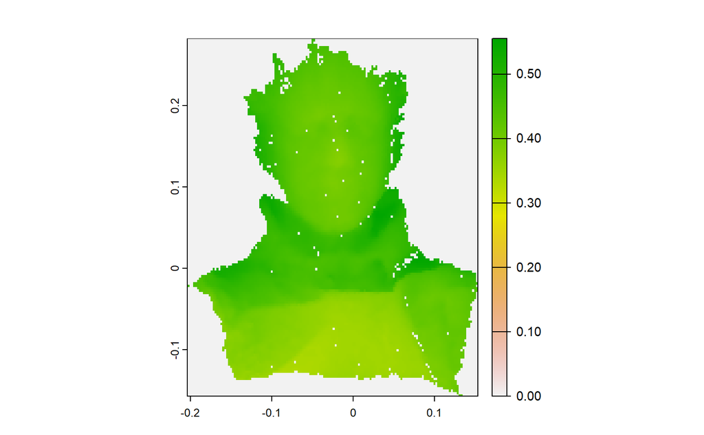

```r
scene2 <- rasterize(x = as.matrix(scene[,1:2], ncol = 2, byrow = TRUE),
               y = r,
               scene[,3],
               fun = mean,
               background = 0)
plot(scene2)
```

Convert the raster to data frame:

```r
scene3 <- as.data.frame(scene2,
                      xy = TRUE)
```

Plot the contours:

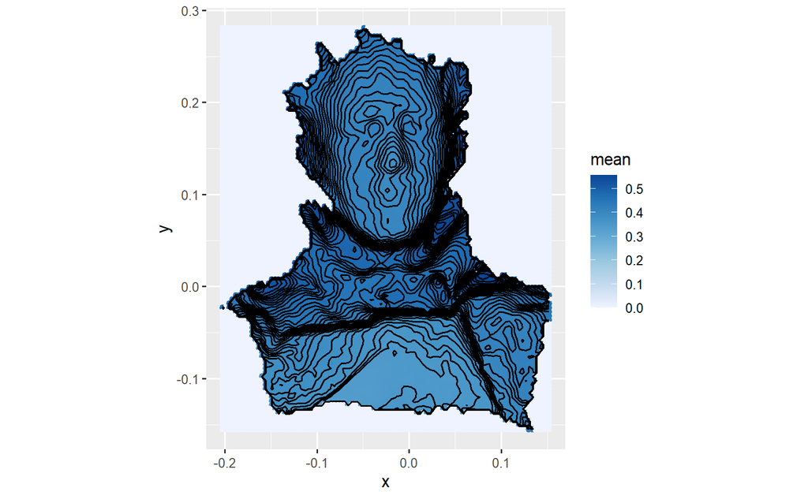

```r
ggplot(data = scene3,
       aes(x, y, z = mean, color = mean)) +
  geom_point() +
  scale_color_distiller(direction = 1) +
  coord_equal() +
  geom_contour(breaks = c(0, 0.3, seq(0.35, 0.55, 0.005), 0.56),
                        color = "black")
```